# Initial data exploration: Regulation of temperature via depth in response to seasonal changes in SST in *Carcharhinus amblyrhynchos*

Ben Cresswell

05 May, 2023

### Introduction

This document provides an initial overview into the temperature and pressure (i.e. depth) data retrieved from the 15 x *Carcharhinus amblyrhychos* tagged with V16 T/P transmitters at Osprey reef. The data span a period of 1 year, including one whole Austral ‘summer’ and ‘winter’ period and all 15 individuals were detected throughout the period (no missing animals!). There are some noticeable patterns in annual SSTs and also in the maximum, mean and minimum temperatures and depths that these sharks experienced on a daily basis, which will hopefully become apparent in the rest of this document…

### Long-term annual SST patterns in the northern Coral Sea

I used Coral Reef Watch’s virtual station for the Northern Coral Sea Islands to obtain long-term monthly mean SSTs for the region. Reefs of the northern Coral Sea experience annual fluctuations of about 4-5°C with peak summer mean temperatures occurring around Jan-Feb and winter minimum means around August. Note that the virtual station that these data pertain to is a polygon centered on Long: 149.35 Lat: -16.00, which is in between Willis Island and Moore reef, approx 250km south of Osprey. I am currently investigating options for calculating long term mean temps for Osprey from other satellite and in-situ data, but I think the pattern will be broadly correct, as will be seen below when we compare to both satellite data for the year of study and the temperatures logged by the sharks. Long term data available at: coralreefwatch.noaa.gov/product/vs/data/northern_coral_sea

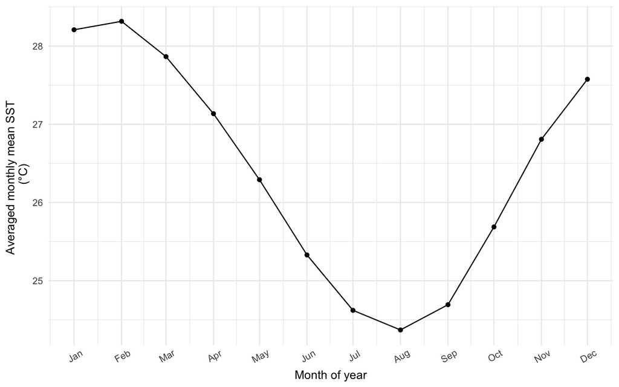

Avg monthly mean SSTs for the Northern Coral Sea Islands (taken from: https://coralreefwatch.noaa.gov/product/vs/data/northern_coral_sea.txt)

### SST variation during study period

SSTs from the two sources are actually very similar in terms of overall patterns. During the period of interest (October 2021 - October 2022), the region experienced temperature fluctuations of approximately this magnitude, as did Osprey Reef itself, with an extended summer of peak temperatures ~30°C from Dec 2021 - Mar 2022.

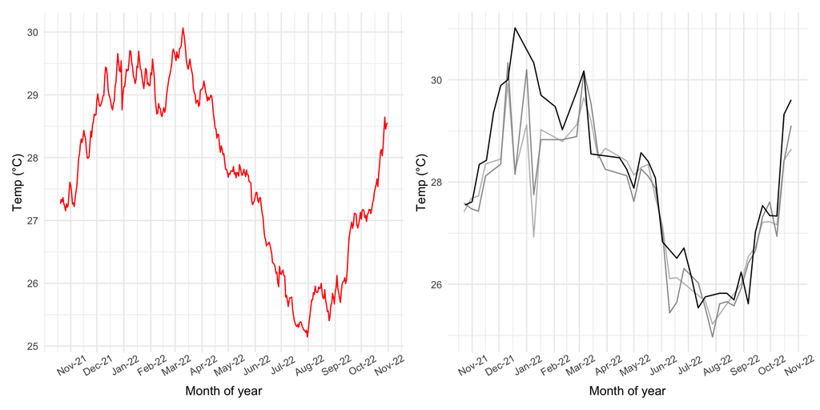

Left fig: Daily mean SSTs for the NCSI region; Fight fig. 8-day mean SSTs taken from MODISA 4micron night in light-grey, 11micron night in mid-grey, 11micron day in dark-grey.